# Namgung_Min_midterm

Min Namgung

3/24/2020

## 1. Introduction

1.1. Variables: Explain the variables you are presenting in your report.  
To start with, I will explain the original datasets. The original datasets have two char datatype variables, and the rest of the variables are all num datatypes. This project runs based on three datasets, which are Covid_Confirmed, Covid_Deaths, and Covid_Recovered. Each original datasets have the same amount of observatinos(482), variables (64), and the same columns. Among the columns, the time series is accumulated by the date.

Original Datasets :

- Covid_Confirmed : this data frame contains the original time_series_19-Covid_Confirmed dataset
- Covid_Deaths : this data frame contains the original time_series_19-Covid_Deaths dataset
- Covid_Recovered : this data frame contains the original time_series_19-Covid_Recovered dataset
  - Province/State : char, this variable contains the state and province name of each country
  - Country/Region : char, this variable contains the country names
  - Lat : num, this variable contains each country’s location’s latitude
  - Long : num, this variable contains each country’s location’s longtitude
  - 1/22/20 : num, this variable contains total number of cases (confirmed, deaths, or recovered) by the date and country
  - 1/23/20 : num, this variable contains total number of cases (confirmed, deaths, or recovered) by the date and country
  - …..
  - 3/21/20 : num, this variable contains total number of cases (confirmed, deaths, or recovered) by the date and country

**2.1 Trend of cases worldwide : Tidy data**

- Covid_Confirmed_worldwide:
  - Date : All of the date series, from original data, has been moved into a date column
  - Confirmed : Total number of worldwide covid confirmed cases by each date
- Covid_Deaths_worldwide :
  - Date : All of the date series, from original data, has been moved into a date column
  - Deaths : Total number of worldwide covid deaths cases by each date
- Covid_Recovered_worldwide :
  - Date : All of the date series, from original data, has been moved into a date column
  - Recovered : Total number of worldwide covid recovered cases by each date
- all_worldwide_covid_data :
  - Date : All of the date series, from original data, has been moved into a date column
  - Confirmed : Total number of worldwide covid confirmed cases by each date, and it is from Covid_Confirmed_worldwide dataset.
  - Deaths : Total number of worldwide covid deaths cases by each date, and it is from Covid_Deaths_worldwide
  - Recovered : Total number of worldwide covid recovered cases by each date, and it is from Covid_Recovered_worldwide

**2.1 Trend of cases worldwide : Draw ggplot graph**

- all_worldwide_covid_data_for_graph :
  - Date : All of the date series, from original data, has been moved into a date column, formatted to date datatype
  - Case : Verify which cases, among confirmed, deaths or recovered, by date.
  - Case_value : Show the number of worldwide cases by date and case

**2.2 Case worldwide by date**

- all_worldwide_covid_data_for_table :
  - Date : All of the date series, from original data, has been moved into a date column
  - Confirmed : Total number of worldwide covid confirmed cases by each date
  - Deaths : Total number of worldwide covid deaths cases by each date
  - Recovered : Total number of worldwide covid recovered cases by each date
  - Active : Total worldwide active cases (confirmed - deaths - recovered) by date
  - Recovery % : Total worldwide recovery % (recovered/confirmed) by date
  - Morailty % : Total worldwide morailty % (deaths/confirmed) by date
- all_worldwide_covid_data_for_table_format
  - Date : All of the date series, from original data, has been moved into a date column
  - Confirmed : Total number of worldwide covid confirmed cases by each date and format it by adding “,”
  - Deaths : Total number of worldwide covid deaths cases by each date and format it by adding “,”
  - Recovered : Total number of worldwide covid recovered cases by each date and format it by adding “,”
  - Active : Total worldwide active cases (confirmed - deaths - recovered) by date and format it adding by “,”
  - Recovery % : Total worldwide recovery % (recovered/confirmed) by date
  - Morailty % : Total worldwide morailty % (deaths/confirmed) by date

**2.3 cases by country table**

- Covid_Confirmed_by_country
  - Country : All countries listed from the original data frame
  - Confirmed : All total covid confirmed cases by country
- Covid_Deaths_by_country
  - Country : All countries listed from the original data frame
  - Deaths : All total covid deaths cases by country
- Covid_Recovered_by_country
  - Country : All countries listed from the original data frame
  - Recovered : All total covid Recovered cases by country
- all_covid_cases_by_country
  - Country : All countries listed from the original data frame
  - Confirmed : Total number of covid confirmed cases by each country
  - Deaths : Total number of covid deaths cases by each country
  - Recovered : Total number of covid recovered cases by each country
- all_covid_cases_by_country_for_table
  - Country : All countries listed from the original data frame
  - Confirmed : Total number of covid confirmed cases by each country in descending order
  - Deaths : Total number of covid deaths cases by each country
  - Recovered : Total number of covid recovered cases by each country
  - Active : Total active cases (confirmed - deaths - recovered) by country
  - Recovery % : Total recovery % (recovered/confirmed) by country
  - Morailty % : Total morailty % (deaths/confirmed) by country
- all_covid_cases_by_country_for_table_format
  - Country : All countries listed from the original data frame
  - Confirmed : Total number of covid confirmed cases by each country in descending order, and format it by adding “,”
  - Deaths : Total number of covid deaths cases by each country, and format it by adding “,”
  - Recovered : Total number of covid recovered cases by each country, and format it by adding “,”
  - Active : Total active cases (confirmed - deaths - recovered) by country, and format it by adding “,”
  - Recovery % : Total recovery % (recovered/confirmed) by country
  - Morailty % : Total morailty % (deaths/confirmed) by country

**2.4 Trends of cases excluding China : Table**

- Covid_Confirmed_exclude_china :
  - Date : All of the date series, from original data, has been moved into a date column
  - Confirmed : Total number of worldwide covid confirmed cases excluding China by each date
- Covid_Deaths_exclude_china :
  - Date : All of the date series, from original data, has been moved into a date column
  - Confirmed : Total number of worldwide covid deaths cases excluding China by each date
- Covid_Recovered_exclude_china :
  - Date : All of the date series, from original data, has been moved into a date column
  - Recovered : Total number of worldwide covid recovered cases excluding China by each date
- all_covid_cases_exclude_China :
  - Date : All of the date series, from original data, has been moved into a date column
  - Confirmed : Total number of worldwide covid confirmed cases excluding China by each date
  - Deaths : Total number of worldwide covid deaths cases excluding China by each date
  - Recovered : Total number of worldwide covid recovered cases excluding China by each date

**2.4 Trends of cases excluding China : Draw ggplot graph**

- all_covid_cases_exclude_China_for_graph :
  - Date : All of the date series, from original data, has been moved into a date column
  - Case : Verify which cases, among confirmed, deaths or recovered, excluding China by date.
  - Case_value : Show the number of worldwide cases excluding China by date and case

**2.5 Case worldwide by date excluding China**

- all_data_exclude_China_for_table :
  - Country : All countries excluding China from original data
  - Confirmed : Total number of covid confirmed cases excluding China by each country, and format it by adding “,”
  - Deaths : Total number of covid deaths cases excluding China by each country, and format it by adding “,”
  - Recovered : Total number of covid recovered cases excluding China by each country, and format it by adding “,”
  - Active : Total active cases (confirmed - deaths - recovered) excluding China by country, and format it by adding “,”
  - Recovery % : Total recovery % (recovered/confirmed) excluding China by country
  - Morailty % : Total morailty % (deaths/confirmed) excluding China by country

**3.1 Trends in Us : Tidy data**

- Covid_Confirmed_US_by_date :
  - Date : All of the date series, from original data, has been moved into a date column
  - Confirmed : Total number of US covid confirmed cases by each date
- Covid_Deaths_US_by_date :
  - Date : All of the date series, from original data, has been moved into a date column
  - Deaths : Total number of US covid Deaths cases by each date
- Covid_Recovered_US_by_date :
  - Date : All of the date series, from original data, has been moved into a date column
  - Recovered : Total number of US covid Recovered cases by each date
- all_covid_case_data_US :
  - Date : All of the date series, from original data, has been moved into a date column
  - Confirmed : Total number of US covid confirmed cases by each date
  - Deaths : Total number of US covid Deaths cases by each date
  - Recovered : Total number of US covid Recovered cases by each date

**3.1 Trends in Us : Draw ggplot graph**

- all_covid_case_US_for_graph :
  - Date : All Date frame from original data is in date column and formatting date datatype
  - Case : Verify which cases, among confirmed, deaths or recovered, in US by date.
  - Case_value : Show the number of US cases by date and case

**3.2 Tables of cases in US by date**

- all_covid_case_data_US_for_table
  - Date : All Date frame from original data is in date column and formatting date datatype
  - Confirmed : Total number of covid confirmed cases in US by each date, and format it by adding “,”
  - Deaths : Total number of covid deaths cases in US by each date, and format it by adding “,”
  - Recovered : Total number of covid recovered cases in US by each date, and format it by adding “,”
  - Active : Total active cases (confirmed - deaths - recovered) in US by each date, and format it byadding “,”
  - Recovery % : Total recovery % (recovered/confirmed) in US by each date
  - Morailty % : Total morailty % (deaths/confirmed) in US by each date

**3.3 Tables of cases in US by state**

- Covid_Confirmed_US_by_state :
  - State : All state names within US
  - Confirmed : Total number of covid confirmed cases in each state
- Covid_Deaths_US_by_state :
  - State : All state names within US
  - Deaths : Total number of covid deaths cases in each state
- Covid_Recovered_US_by_state :
  - State : All state names within US
  - Recovered : Total number of covid recovered cases in each state
- all_US_covid_data_by_state :
  - State : All state names within US
  - Confirmed : Total number of covid confirmed cases in each state
  - Deaths : Total number of covid deaths cases in each state
  - Recovered : Total number of covid recovered cases in each state
- all_US_covid_data_by_state_for_table :
  - State : All state names within US
  - Confirmed : Total number of covid confirmed cases in each state, and format it by adding “,”
  - Deaths : Total number of covid deaths cases in each state, and format it by adding “,”
  - Recovered : Total number of covid recovered cases in each state, and format it by adding “,”
  - Active : Total active cases (confirmed - deaths - recovered) in each US date, and format it by adding “,”
  - Recovery % : Total recovery % (recovered/confirmed) in each US date
  - Morailty % : Total morailty % (deaths/confirmed) in each US date

**4.1 Covid predictions cases by country**

- all_data_by_country_rate :
  - Country : all country names from the original data set
  - active % : active % by total worldwide active cases (active / sum of all worldwide active cases) * 100
  - expected recovery : calculation (active/recovery %) and round to three decimal points
  - expected mortailty : calculation (active/ mortailty %) / 100 and round to three decimal points
- Total_active: this is a variable which contains all sum of active elements from each country
- all_data_by_country_rate_format :
  - Country : all country names from the original data set
  - active % : active % by total worldwide active cases (active / sum of all worldwide active cases) * 100 in descending order, and format it by adding “,”
  - expected recovery : calculation (active/recovery %) and round to three decimal points, and format it by adding “,”
  - expected mortailty : calculation (active/ mortailty %) / 100 and round to three decimal points, and format it by adding “,”

**4.2 China and Italy Covid Confirmed cases by date**

- Covid_Confirmed_china :
  - Date : All of the date series, from original data, has been moved into a date column
  - Confirmed : All covid confirmed cases filtered by China by date
- Covid_Confirmed_Italy :
  - Date : All of the date series, from original data, has been moved into a date column
  - Confirmed : All covid confirmed cases filtered by Italy by date
- China_Italy_Covid_Confirmed :
  - Date : All of the date series, from original data, has been moved into a date column
  - China_Confirmed : All covid confirmed cases filtered by China by date
  - Italy_Confirmed : All covid confirmed cases filtered by Italy by date
- China_Italy_Covid_Confirmed_for_graph:
  - Date : All of the date series, from original data, has been moved into a date column
  - Cases : Verify either china_confirmed or Italy_confirmed
  - Confirmed : All covid confirmed cases filtered by either China or Italy by date

## 1.1 Import library

This project imports 4 different libraries, tidyverse, readr, dplyr, and ggplot2.

## 1.2 Import data

The three datasets are imported by the read_csv() function: covid_confirmed variable have covid-confirmed.csv, Covid_Deaths variable have covid-deaths.csv and covid_recovered variable have covid-recovered.csv dataset.

## 1.3 Tidy data

To tidy each datasets, I drop the lat and long columns, since it won’t be used in the project. Then, rename Country/Region column to Country, and Province/State column to State. This is because it makes it easier to join or filter data from these two columns. Also, I intentionally leave the State column with NA rows, because even though the State column will be used, the NA rows in the State column will not be used in this project. So, the NA rows will not affect the results.

## 2.1 Trend of cases worldwide

Before I draw the graph, tidying the three datasets is necessary. I tidy each case (each data frame) by each date, so all the date series are now under the date column. Hence, **Covid_Confirmed_worldwide, Covid_Deaths_worldwide, Covid_Recovered_worldwide** are combined into total cases by each date. Then, add these three tidied datasets into one data frame, **all_worldwide_covid_data**. so the **all_worldwide_covid_data** has date, confirmed, deaths and recovered columns.

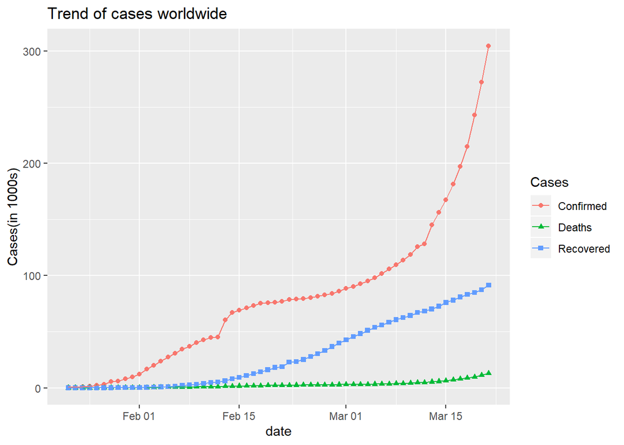

## 2.2 Cases worldwide by date

| Date | Confirmed | Deaths | Recovered | active | recovery.. | morailty.. |
| --- | --- | --- | --- | --- | --- | --- |
| 2020-01-22 | 555 | 17 | 28 | 510 | 5.045 | 3.063 |
| 2020-01-23 | 653 | 18 | 30 | 605 | 4.594 | 2.757 |
| 2020-01-24 | 941 | 26 | 36 | 879 | 3.826 | 2.763 |
| 2020-01-25 | 1,434 | 42 | 39 | 1,353 | 2.720 | 2.929 |
| 2020-01-26 | 2,118 | 56 | 52 | 2,010 | 2.455 | 2.644 |
| 2020-01-27 | 2,927 | 82 | 61 | 2,784 | 2.084 | 2.802 |
| 2020-01-28 | 5,578 | 131 | 107 | 5,340 | 1.918 | 2.349 |
| 2020-01-29 | 6,166 | 133 | 126 | 5,907 | 2.043 | 2.157 |
| 2020-01-30 | 8,234 | 171 | 143 | 7,920 | 1.737 | 2.077 |
| 2020-01-31 | 9,927 | 213 | 222 | 9,492 | 2.236 | 2.146 |
| 2020-02-01 | 12,038 | 259 | 284 | 11,495 | 2.359 | 2.152 |
| 2020-02-02 | 16,787 | 362 | 472 | 15,953 | 2.812 | 2.156 |
| 2020-02-03 | 19,881 | 426 | 623 | 18,832 | 3.134 | 2.143 |
| 2020-02-04 | 23,892 | 492 | 852 | 22,548 | 3.566 | 2.059 |
| 2020-02-05 | 27,635 | 564 | 1,124 | 25,947 | 4.067 | 2.041 |
| 2020-02-06 | 30,817 | 634 | 1,487 | 28,696 | 4.825 | 2.057 |
| 2020-02-07 | 34,391 | 719 | 2,011 | 31,661 | 5.847 | 2.091 |
| 2020-02-08 | 37,120 | 806 | 2,616 | 33,698 | 7.047 | 2.171 |
| 2020-02-09 | 40,150 | 906 | 3,244 | 36,000 | 8.080 | 2.257 |
| 2020-02-10 | 42,762 | 1,013 | 3,946 | 37,803 | 9.228 | 2.369 |
| 2020-02-11 | 44,802 | 1,113 | 4,683 | 39,006 | 10.453 | 2.484 |
| 2020-02-12 | 45,221 | 1,118 | 5,150 | 38,953 | 11.389 | 2.472 |
| 2020-02-13 | 60,368 | 1,371 | 6,295 | 52,702 | 10.428 | 2.271 |
| 2020-02-14 | 66,885 | 1,523 | 8,058 | 57,304 | 12.048 | 2.277 |
| 2020-02-15 | 69,030 | 1,666 | 9,395 | 57,969 | 13.610 | 2.413 |
| 2020-02-16 | 71,224 | 1,770 | 10,865 | 58,589 | 15.255 | 2.485 |
| 2020-02-17 | 73,258 | 1,868 | 12,583 | 58,807 | 17.176 | 2.550 |
| 2020-02-18 | 75,136 | 2,007 | 14,352 | 58,777 | 19.101 | 2.671 |
| 2020-02-19 | 75,639 | 2,122 | 16,121 | 57,396 | 21.313 | 2.805 |
| 2020-02-20 | 76,197 | 2,247 | 18,177 | 55,773 | 23.855 | 2.949 |
| 2020-02-21 | 76,823 | 2,251 | 18,890 | 55,682 | 24.589 | 2.930 |
| 2020-02-22 | 78,579 | 2,458 | 22,886 | 53,235 | 29.125 | 3.128 |
| 2020-02-23 | 78,965 | 2,469 | 23,394 | 53,102 | 29.626 | 3.127 |
| 2020-02-24 | 79,568 | 2,629 | 25,227 | 51,712 | 31.705 | 3.304 |
| 2020-02-25 | 80,413 | 2,708 | 27,905 | 49,800 | 34.702 | 3.368 |
| 2020-02-26 | 81,395 | 2,770 | 30,384 | 48,241 | 37.329 | 3.403 |
| 2020-02-27 | 82,754 | 2,814 | 33,277 | 46,663 | 40.212 | 3.400 |
| 2020-02-28 | 84,120 | 2,872 | 36,711 | 44,537 | 43.641 | 3.414 |
| 2020-02-29 | 86,011 | 2,941 | 39,782 | 43,288 | 46.252 | 3.419 |
| 2020-03-01 | 88,369 | 2,996 | 42,716 | 42,657 | 48.338 | 3.390 |
| 2020-03-02 | 90,306 | 3,085 | 45,602 | 41,619 | 50.497 | 3.416 |
| 2020-03-03 | 92,840 | 3,160 | 48,228 | 41,452 | 51.947 | 3.404 |
| 2020-03-04 | 95,120 | 3,254 | 51,170 | 40,696 | 53.795 | 3.421 |
| 2020-03-05 | 97,882 | 3,348 | 53,796 | 40,738 | 54.960 | 3.420 |
| 2020-03-06 | 101,784 | 3,460 | 55,865 | 42,459 | 54.886 | 3.399 |
| 2020-03-07 | 105,821 | 3,558 | 58,358 | 43,905 | 55.148 | 3.362 |
| 2020-03-08 | 109,795 | 3,802 | 60,694 | 45,299 | 55.279 | 3.463 |
| 2020-03-09 | 113,561 | 3,988 | 62,494 | 47,079 | 55.031 | 3.512 |
| 2020-03-10 | 118,592 | 4,262 | 64,404 | 49,926 | 54.307 | 3.594 |
| 2020-03-11 | 125,865 | 4,615 | 67,003 | 54,247 | 53.234 | 3.667 |
| 2020-03-12 | 128,343 | 4,720 | 68,324 | 55,299 | 53.235 | 3.678 |
| 2020-03-13 | 145,193 | 5,404 | 70,251 | 69,538 | 48.385 | 3.722 |
| 2020-03-14 | 156,094 | 5,819 | 72,624 | 77,651 | 46.526 | 3.728 |
| 2020-03-15 | 167,446 | 6,440 | 76,034 | 84,972 | 45.408 | 3.846 |
| 2020-03-16 | 181,527 | 7,126 | 78,088 | 96,313 | 43.017 | 3.926 |
| 2020-03-17 | 197,142 | 7,905 | 80,840 | 108,397 | 41.006 | 4.010 |
| 2020-03-18 | 214,910 | 8,733 | 83,207 | 122,970 | 38.717 | 4.064 |
| 2020-03-19 | 242,708 | 9,867 | 84,854 | 147,987 | 34.961 | 4.065 |
| 2020-03-20 | 272,166 | 11,299 | 87,256 | 173,611 | 32.060 | 4.152 |
| 2020-03-21 | 304,524 | 12,973 | 91,499 | 200,052 | 30.047 | 4.260 |

The **all_worldwide_covid_data_for_table** shows worldwide covid cases by date, along with covid active, recovery % and morailty %. The table above is shown from **all_worldwide_covid_data_for_table_format** after formatting **all_worldwide_covid_data_for_table**. By this table, I found that Covid confirmed cases are greatly growing and the death rates remain relatively steady.

## 2.3 Cases by country table

| Country | Confirmed | Deaths | Recovered | active | recovery.. | morailty.. |
| --- | --- | --- | --- | --- | --- | --- |
| China | 81,305 | 3,259 | 71,857 | 6,189 | 88.380 | 4.008 |
| Italy | 53,578 | 4,825 | 6,072 | 42,681 | 11.333 | 9.006 |
| US | 25,489 | 307 | 0 | 25,182 | 0.000 | 1.204 |
| Spain | 25,374 | 1,375 | 2,125 | 21,874 | 8.375 | 5.419 |
| Germany | 22,213 | 84 | 233 | 21,896 | 1.049 | 0.378 |
| Iran | 20,610 | 1,556 | 7,635 | 11,419 | 37.045 | 7.550 |
| France | 14,431 | 562 | 12 | 13,857 | 0.083 | 3.894 |
| Korea, South | 8,799 | 102 | 1,540 | 7,157 | 17.502 | 1.159 |
| Switzerland | 6,575 | 75 | 15 | 6,485 | 0.228 | 1.141 |
| United Kingdom | 5,067 | 234 | 67 | 4,766 | 1.322 | 4.618 |
| Netherlands | 3,640 | 137 | 2 | 3,501 | 0.055 | 3.764 |
| Belgium | 2,815 | 67 | 263 | 2,485 | 9.343 | 2.380 |
| Austria | 2,814 | 8 | 9 | 2,797 | 0.320 | 0.284 |
| Norway | 2,118 | 7 | 1 | 2,110 | 0.047 | 0.331 |
| Sweden | 1,763 | 20 | 16 | 1,727 | 0.908 | 1.134 |
| Denmark | 1,420 | 13 | 1 | 1,406 | 0.070 | 0.915 |
| Portugal | 1,280 | 12 | 5 | 1,263 | 0.391 | 0.938 |
| Canada | 1,278 | 19 | 10 | 1,249 | 0.782 | 1.487 |
| Malaysia | 1,183 | 4 | 114 | 1,065 | 9.637 | 0.338 |
| Australia | 1,071 | 7 | 26 | 1,038 | 2.428 | 0.654 |
| Brazil | 1,021 | 15 | 2 | 1,004 | 0.196 | 1.469 |
| Japan | 1,007 | 35 | 232 | 740 | 23.039 | 3.476 |
| Czechia | 995 | 0 | 6 | 989 | 0.603 | 0.000 |
| Israel | 883 | 1 | 36 | 846 | 4.077 | 0.113 |
| Ireland | 785 | 3 | 5 | 777 | 0.637 | 0.382 |
| Pakistan | 730 | 3 | 13 | 714 | 1.781 | 0.411 |
| Cruise Ship | 712 | 8 | 325 | 379 | 45.646 | 1.124 |
| Luxembourg | 670 | 8 | 0 | 662 | 0.000 | 1.194 |
| Turkey | 670 | 9 | 0 | 661 | 0.000 | 1.343 |
| Chile | 537 | 0 | 6 | 531 | 1.117 | 0.000 |

[output cut: 136 more lines]

The **all_covid_cases_by_country** shows total covid cases by country, along with covid active, recovery % and morailty %. The table above is shown from **all_covid_cases_by_country_desc** after formatting of descending order in confrimed cases and formatting of confirmed, deaths, recovered, and active columns in **all_worldwide_covid_data_for_table**. By this table, I found that China contains the most confirmed cases and the highest recovery rate.

## 2.4 Trend of Cases Excluding China

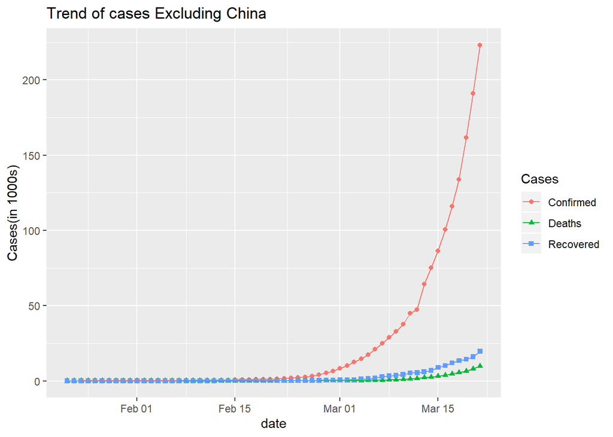

To draw the above graph, the data sets are tidied in a table of **all_covid_cases_exclude_China**. Tidying all datasets filtered by excluding China, and adding Confirmed, deaths, and recovered cases in one data frame. In **all_covid_cases_exclude_China** data frame, covid cases are under the cases column excluding China. In the cases column, it verify cases among confirmed, deaths, or recovered with the number of worldwide cases, excluding China, by date. The graph **Trend of cases Excluding China** shows that confirmed cases is much higher than deaths and recovered cases. Deaths and recovered cases do not have very many differences.

## 2.5 Cases worldwide by date, excluding China

| Date | Confirmed | Deaths | Recovered | active | recovery.. | morailty.. |
| --- | --- | --- | --- | --- | --- | --- |
| 2020-01-22 | 7 | 0 | 0 | 7 | 0.000 | 0.000 |
| 2020-01-23 | 10 | 0 | 0 | 10 | 0.000 | 0.000 |
| 2020-01-24 | 21 | 0 | 0 | 21 | 0.000 | 0.000 |
| 2020-01-25 | 28 | 0 | 0 | 28 | 0.000 | 0.000 |
| 2020-01-26 | 43 | 0 | 3 | 40 | 6.977 | 0.000 |
| 2020-01-27 | 50 | 0 | 3 | 47 | 6.000 | 0.000 |
| 2020-01-28 | 69 | 0 | 6 | 63 | 8.696 | 0.000 |
| 2020-01-29 | 79 | 0 | 6 | 73 | 7.595 | 0.000 |
| 2020-01-30 | 93 | 0 | 8 | 85 | 8.602 | 0.000 |
| 2020-01-31 | 125 | 0 | 8 | 117 | 6.400 | 0.000 |
| 2020-02-01 | 147 | 0 | 9 | 138 | 6.122 | 0.000 |
| 2020-02-02 | 157 | 1 | 9 | 147 | 5.732 | 0.637 |
| 2020-02-03 | 165 | 1 | 9 | 155 | 5.455 | 0.606 |
| 2020-02-04 | 185 | 1 | 9 | 175 | 4.865 | 0.541 |
| 2020-02-05 | 195 | 1 | 9 | 185 | 4.615 | 0.513 |
| 2020-02-06 | 230 | 1 | 10 | 219 | 4.348 | 0.435 |
| 2020-02-07 | 281 | 1 | 12 | 268 | 4.270 | 0.356 |
| 2020-02-08 | 306 | 1 | 20 | 285 | 6.536 | 0.327 |
| 2020-02-09 | 321 | 1 | 25 | 295 | 7.788 | 0.312 |
| 2020-02-10 | 408 | 1 | 28 | 379 | 6.863 | 0.245 |
| 2020-02-11 | 416 | 1 | 47 | 368 | 11.298 | 0.240 |
| 2020-02-12 | 462 | 1 | 68 | 393 | 14.719 | 0.216 |
| 2020-02-13 | 473 | 2 | 78 | 393 | 16.490 | 0.423 |
| 2020-02-14 | 527 | 2 | 81 | 444 | 15.370 | 0.380 |
| 2020-02-15 | 617 | 3 | 97 | 517 | 15.721 | 0.486 |
| 2020-02-16 | 711 | 4 | 110 | 597 | 15.471 | 0.563 |
| 2020-02-17 | 824 | 4 | 121 | 699 | 14.684 | 0.485 |
| 2020-02-18 | 925 | 4 | 146 | 775 | 15.784 | 0.432 |
| 2020-02-19 | 1,020 | 6 | 159 | 855 | 15.588 | 0.588 |
| 2020-02-20 | 1,120 | 9 | 163 | 948 | 14.554 | 0.804 |
| 2020-02-21 | 1,273 | 13 | 186 | 1,074 | 14.611 | 1.021 |
| 2020-02-22 | 1,578 | 15 | 187 | 1,376 | 11.850 | 0.951 |
| 2020-02-23 | 1,943 | 24 | 207 | 1,712 | 10.654 | 1.235 |
| 2020-02-24 | 2,327 | 34 | 212 | 2,081 | 9.110 | 1.461 |
| 2020-02-25 | 2,659 | 43 | 229 | 2,387 | 8.612 | 1.617 |
| 2020-02-26 | 3,229 | 53 | 300 | 2,876 | 9.291 | 1.641 |
| 2020-02-27 | 4,154 | 68 | 347 | 3,739 | 8.353 | 1.637 |
| 2020-02-28 | 5,192 | 82 | 382 | 4,728 | 7.357 | 1.579 |
| 2020-02-29 | 6,655 | 104 | 462 | 6,089 | 6.942 | 1.563 |
| 2020-03-01 | 8,437 | 124 | 554 | 7,759 | 6.566 | 1.470 |
| 2020-03-02 | 10,170 | 171 | 748 | 9,251 | 7.355 | 1.681 |
| 2020-03-03 | 12,579 | 213 | 778 | 11,588 | 6.185 | 1.693 |
| 2020-03-04 | 14,734 | 271 | 1,169 | 13,294 | 7.934 | 1.839 |
| 2020-03-05 | 17,345 | 333 | 1,504 | 15,508 | 8.671 | 1.920 |
| 2020-03-06 | 21,094 | 416 | 1,921 | 18,757 | 9.107 | 1.972 |
| 2020-03-07 | 25,051 | 486 | 2,819 | 21,746 | 11.253 | 1.940 |
| 2020-03-08 | 28,972 | 702 | 3,306 | 24,964 | 11.411 | 2.423 |
| 2020-03-09 | 32,701 | 865 | 3,690 | 28,146 | 11.284 | 2.645 |
| 2020-03-10 | 37,705 | 1,123 | 4,223 | 32,359 | 11.200 | 2.978 |
| 2020-03-11 | 44,944 | 1,454 | 5,359 | 38,131 | 11.924 | 3.235 |
| 2020-03-12 | 47,411 | 1,548 | 5,423 | 40,440 | 11.438 | 3.265 |
| 2020-03-13 | 64,248 | 2,224 | 6,055 | 55,969 | 9.424 | 3.462 |
| 2020-03-14 | 75,117 | 2,626 | 6,964 | 65,527 | 9.271 | 3.496 |
| 2020-03-15 | 86,443 | 3,237 | 9,017 | 74,189 | 10.431 | 3.745 |
| 2020-03-16 | 100,494 | 3,909 | 10,178 | 86,407 | 10.128 | 3.890 |
| 2020-03-17 | 116,084 | 4,675 | 12,042 | 99,367 | 10.374 | 4.027 |
| 2020-03-18 | 133,808 | 5,492 | 13,452 | 114,864 | 10.053 | 4.104 |
| 2020-03-19 | 161,552 | 6,618 | 14,319 | 140,615 | 8.863 | 4.097 |
| 2020-03-20 | 190,916 | 8,046 | 15,990 | 166,880 | 8.375 | 4.214 |
| 2020-03-21 | 223,219 | 9,714 | 19,642 | 193,863 | 8.799 | 4.352 |

The **all_data_exclude_China_for_table** shows the total covid cases by country, along with covid active, recovery % and morailty %. The table above is shown from **all_data_exclude_China_for_table** after formatting confrimed cases and formatting confirmed, deaths, recovered, and active columns in **all_worldwide_covid_data_for_table**. By this table, I found that the initial statement of covid confirmed cases excluding China were not as severe as they are currently. Also, confirmed cases are much higher than recovery case, so I assume covid is difficult to completely recover from.

## 3.1. Trend in the U.S.

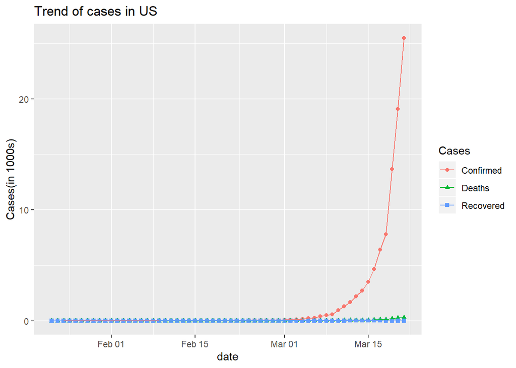

To draw the above graph, the three data sets are combined into one dataset, **all_covid_case_data_US** data frame. In the combined datasets, US covid cases are under the cases column. In the cases column, it verify cases among confirmed, deaths, or recovered, with the number of US covid cases by date. In **all_covid_case_US_for_graph** data frame, covid cases are under the cases column. In the cases column, it verifies cases among confirmed, deaths, or recovered with the number of US cases. The graph **Trend of cases in US** shows that confirmed cases is much higher than deaths and recovered cases. And US deaths and recovered cases contain very little change by date.

## 3.2 Table of cases in the U.S. by date

| Date | Confirmed | Deaths | Recovered | active | recovery.. | morailty.. |
| --- | --- | --- | --- | --- | --- | --- |
| 2020-01-22 | 1 | 0 | 0 | 1 | 0.000 | 0.000 |
| 2020-01-23 | 1 | 0 | 0 | 1 | 0.000 | 0.000 |
| 2020-01-24 | 2 | 0 | 0 | 2 | 0.000 | 0.000 |
| 2020-01-25 | 2 | 0 | 0 | 2 | 0.000 | 0.000 |
| 2020-01-26 | 5 | 0 | 0 | 5 | 0.000 | 0.000 |
| 2020-01-27 | 5 | 0 | 0 | 5 | 0.000 | 0.000 |
| 2020-01-28 | 5 | 0 | 0 | 5 | 0.000 | 0.000 |
| 2020-01-29 | 5 | 0 | 0 | 5 | 0.000 | 0.000 |
| 2020-01-30 | 5 | 0 | 0 | 5 | 0.000 | 0.000 |
| 2020-01-31 | 7 | 0 | 0 | 7 | 0.000 | 0.000 |
| 2020-02-01 | 8 | 0 | 0 | 8 | 0.000 | 0.000 |
| 2020-02-02 | 8 | 0 | 0 | 8 | 0.000 | 0.000 |
| 2020-02-03 | 11 | 0 | 0 | 11 | 0.000 | 0.000 |
| 2020-02-04 | 11 | 0 | 0 | 11 | 0.000 | 0.000 |
| 2020-02-05 | 11 | 0 | 0 | 11 | 0.000 | 0.000 |
| 2020-02-06 | 11 | 0 | 0 | 11 | 0.000 | 0.000 |
| 2020-02-07 | 11 | 0 | 0 | 11 | 0.000 | 0.000 |
| 2020-02-08 | 11 | 0 | 0 | 11 | 0.000 | 0.000 |
| 2020-02-09 | 11 | 0 | 3 | 8 | 27.273 | 0.000 |
| 2020-02-10 | 11 | 0 | 3 | 8 | 27.273 | 0.000 |
| 2020-02-11 | 12 | 0 | 3 | 9 | 25.000 | 0.000 |
| 2020-02-12 | 12 | 0 | 3 | 9 | 25.000 | 0.000 |
| 2020-02-13 | 13 | 0 | 3 | 10 | 23.077 | 0.000 |
| 2020-02-14 | 13 | 0 | 3 | 10 | 23.077 | 0.000 |
| 2020-02-15 | 13 | 0 | 3 | 10 | 23.077 | 0.000 |
| 2020-02-16 | 13 | 0 | 3 | 10 | 23.077 | 0.000 |
| 2020-02-17 | 13 | 0 | 3 | 10 | 23.077 | 0.000 |
| 2020-02-18 | 13 | 0 | 3 | 10 | 23.077 | 0.000 |
| 2020-02-19 | 13 | 0 | 3 | 10 | 23.077 | 0.000 |
| 2020-02-20 | 13 | 0 | 3 | 10 | 23.077 | 0.000 |
| 2020-02-21 | 15 | 0 | 5 | 10 | 33.333 | 0.000 |
| 2020-02-22 | 15 | 0 | 5 | 10 | 33.333 | 0.000 |
| 2020-02-23 | 15 | 0 | 5 | 10 | 33.333 | 0.000 |
| 2020-02-24 | 51 | 0 | 5 | 46 | 9.804 | 0.000 |
| 2020-02-25 | 51 | 0 | 6 | 45 | 11.765 | 0.000 |
| 2020-02-26 | 57 | 0 | 6 | 51 | 10.526 | 0.000 |
| 2020-02-27 | 58 | 0 | 6 | 52 | 10.345 | 0.000 |
| 2020-02-28 | 60 | 0 | 7 | 53 | 11.667 | 0.000 |
| 2020-02-29 | 68 | 1 | 7 | 60 | 10.294 | 1.471 |
| 2020-03-01 | 74 | 1 | 7 | 66 | 9.459 | 1.351 |
| 2020-03-02 | 98 | 6 | 7 | 85 | 7.143 | 6.122 |
| 2020-03-03 | 118 | 7 | 7 | 104 | 5.932 | 5.932 |
| 2020-03-04 | 149 | 11 | 7 | 131 | 4.698 | 7.383 |
| 2020-03-05 | 217 | 12 | 7 | 198 | 3.226 | 5.530 |
| 2020-03-06 | 262 | 14 | 7 | 241 | 2.672 | 5.344 |
| 2020-03-07 | 402 | 17 | 7 | 378 | 1.741 | 4.229 |
| 2020-03-08 | 518 | 21 | 7 | 490 | 1.351 | 4.054 |
| 2020-03-09 | 583 | 22 | 7 | 554 | 1.201 | 3.774 |
| 2020-03-10 | 959 | 28 | 8 | 923 | 0.834 | 2.920 |
| 2020-03-11 | 1,281 | 36 | 8 | 1,237 | 0.625 | 2.810 |
| 2020-03-12 | 1,663 | 40 | 12 | 1,611 | 0.722 | 2.405 |
| 2020-03-13 | 2,179 | 47 | 12 | 2,120 | 0.551 | 2.157 |
| 2020-03-14 | 2,727 | 54 | 12 | 2,661 | 0.440 | 1.980 |
| 2020-03-15 | 3,499 | 63 | 12 | 3,424 | 0.343 | 1.801 |
| 2020-03-16 | 4,632 | 85 | 17 | 4,530 | 0.367 | 1.835 |
| 2020-03-17 | 6,421 | 108 | 17 | 6,296 | 0.265 | 1.682 |
| 2020-03-18 | 7,783 | 118 | 0 | 7,665 | 0.000 | 1.516 |
| 2020-03-19 | 13,677 | 200 | 0 | 13,477 | 0.000 | 1.462 |
| 2020-03-20 | 19,100 | 244 | 0 | 18,856 | 0.000 | 1.277 |
| 2020-03-21 | 25,489 | 307 | 0 | 25,182 | 0.000 | 1.204 |

The **all_covid_case_data_US_for_table** shows the total covid cases in US by date, along with covid active, recovery % and morailty %. The table above is shown from **all_covid_case_data_US_for_table** after the formatting of confirmed, deaths, recovered, and active columns in **all_covid_case_data_US_for_table**. By this table, I found that recovery cases, starting March 18 are no longer recorded.

## 3.3 Table of cases in the U.S. by state

| State | Confirmed | Deaths | Recovered | active | recovery.. | morailty.. |
| --- | --- | --- | --- | --- | --- | --- |
| New York | 11,710 | 60 | 0 | 11,650 | 0 | 0.512 |
| Washington | 1,793 | 94 | 0 | 1,699 | 0 | 5.243 |
| California | 1,364 | 24 | 0 | 1,340 | 0 | 1.760 |
| New Jersey | 1,327 | 16 | 0 | 1,311 | 0 | 1.206 |
| Michigan | 788 | 5 | 0 | 783 | 0 | 0.635 |
| Illinois | 753 | 6 | 0 | 747 | 0 | 0.797 |
| Florida | 659 | 13 | 0 | 646 | 0 | 1.973 |
| Louisiana | 585 | 16 | 0 | 569 | 0 | 2.735 |
| Texas | 581 | 5 | 0 | 576 | 0 | 0.861 |
| Massachusetts | 525 | 1 | 0 | 524 | 0 | 0.190 |
| Georgia | 507 | 14 | 0 | 493 | 0 | 2.761 |
| Pennsylvania | 396 | 2 | 0 | 394 | 0 | 0.505 |
| Colorado | 390 | 4 | 0 | 386 | 0 | 1.026 |
| Tennessee | 371 | 1 | 0 | 370 | 0 | 0.270 |
| Wisconsin | 282 | 4 | 0 | 278 | 0 | 1.418 |
| North Carolina | 253 | 0 | 0 | 253 | 0 | 0.000 |
| Ohio | 248 | 3 | 0 | 245 | 0 | 1.210 |
| Connecticut | 194 | 4 | 0 | 190 | 0 | 2.062 |
| Maryland | 193 | 2 | 0 | 191 | 0 | 1.036 |
| South Carolina | 171 | 3 | 0 | 168 | 0 | 1.754 |
| Nevada | 161 | 2 | 0 | 159 | 0 | 1.242 |
| Virginia | 156 | 2 | 0 | 154 | 0 | 1.282 |
| Mississippi | 140 | 1 | 0 | 139 | 0 | 0.714 |
| Minnesota | 138 | 1 | 0 | 137 | 0 | 0.725 |
| Utah | 136 | 0 | 0 | 136 | 0 | 0.000 |
| Alabama | 131 | 0 | 0 | 131 | 0 | 0.000 |
| Indiana | 128 | 4 | 0 | 124 | 0 | 3.125 |
| Arkansas | 122 | 0 | 0 | 122 | 0 | 0.000 |
| Arizona | 118 | 1 | 0 | 117 | 0 | 0.847 |
| Oregon | 114 | 5 | 0 | 109 | 0 | 4.386 |
| Kentucky | 87 | 3 | 0 | 84 | 0 | 3.448 |
| District of Columbia | 77 | 1 | 0 | 76 | 0 | 1.299 |
| Missouri | 74 | 3 | 0 | 71 | 0 | 4.054 |
| Maine | 70 | 0 | 0 | 70 | 0 | 0.000 |
| Iowa | 68 | 0 | 0 | 68 | 0 | 0.000 |
| Rhode Island | 66 | 0 | 0 | 66 | 0 | 0.000 |
| Kansas | 57 | 2 | 0 | 55 | 0 | 3.509 |
| New Hampshire | 55 | 0 | 0 | 55 | 0 | 0.000 |
| Oklahoma | 53 | 1 | 0 | 52 | 0 | 1.887 |
| Diamond Princess | 49 | 0 | 0 | 49 | 0 | 0.000 |
| Delaware | 45 | 0 | 0 | 45 | 0 | 0.000 |
| New Mexico | 43 | 0 | 0 | 43 | 0 | 0.000 |
| Nebraska | 38 | 0 | 0 | 38 | 0 | 0.000 |
| Hawaii | 37 | 0 | 0 | 37 | 0 | 0.000 |
| Idaho | 36 | 0 | 0 | 36 | 0 | 0.000 |
| Vermont | 29 | 2 | 0 | 27 | 0 | 6.897 |
| North Dakota | 28 | 0 | 0 | 28 | 0 | 0.000 |
| Grand Princess | 23 | 0 | 0 | 23 | 0 | 0.000 |
| Wyoming | 23 | 0 | 0 | 23 | 0 | 0.000 |
| Montana | 21 | 0 | 0 | 21 | 0 | 0.000 |
| Puerto Rico | 21 | 1 | 0 | 20 | 0 | 4.762 |
| Alaska | 15 | 0 | 0 | 15 | 0 | 0.000 |
| Guam | 15 | 0 | 0 | 15 | 0 | 0.000 |
| South Dakota | 14 | 1 | 0 | 13 | 0 | 7.143 |
| West Virginia | 8 | 0 | 0 | 8 | 0 | 0.000 |
| Virgin Islands | 3 | 0 | 0 | 3 | 0 | 0.000 |

To tidy data by US states, I drop the rows which has cities with area code, which is the same as the sample 2.3 question. This is because the rows end up to be 0, in the very last date column, which accumulates all the cases by area. The **all_US_covid_data_by_state_for_table** shows the total covid cases in each US state, along with covid active, recovery % and morailty %. The table above is shown from **all_US_covid_data_by_state_for_table** after the formatting of confirmed, deaths, recovered, and active columns in **all_US_covid_data_by_state_for_table**.

## 4. Perform an analysis of your own

Table title: **Worldwide Covid active %, expected recovery and expected mortailty by descending order in active %**

| country | active.. | expected.recovery | expected.mortailty |
| --- | --- | --- | --- |
| Italy | 21.335 | 37.661 | 47.392 |
| US | 12.588 | 0.000 | 209.153 |
| Germany | 10.945 | 208.732 | 579.259 |
| Spain | 10.934 | 26.118 | 40.365 |
| France | 6.927 | 1,669.518 | 35.586 |
| Iran | 5.708 | 3.082 | 15.125 |
| Korea, South | 3.578 | 4.089 | 61.752 |
| Switzerland | 3.242 | 284.430 | 56.836 |
| China | 3.094 | 0.700 | 15.442 |
| United Kingdom | 2.382 | 36.051 | 10.320 |
| Netherlands | 1.750 | 636.545 | 9.301 |
| Austria | 1.398 | 87.406 | 98.486 |
| Belgium | 1.242 | 2.660 | 10.441 |
| Norway | 1.055 | 448.936 | 63.746 |
| Sweden | 0.863 | 19.020 | 15.229 |
| Denmark | 0.703 | 200.857 | 15.366 |
| Portugal | 0.631 | 32.302 | 13.465 |
| Canada | 0.624 | 15.972 | 8.399 |
| Malaysia | 0.532 | 1.105 | 31.509 |
| Australia | 0.519 | 4.275 | 15.872 |
| Brazil | 0.502 | 51.224 | 6.835 |
| Czechia | 0.494 | 16.401 | 0.000 |
| Israel | 0.423 | 2.075 | 74.867 |
| Ireland | 0.388 | 12.198 | 20.340 |
| Japan | 0.370 | 0.321 | 2.129 |
| Pakistan | 0.357 | 4.009 | 17.372 |
| Luxembourg | 0.331 | 0.000 | 5.544 |
| Turkey | 0.330 | 0.000 | 4.922 |
| Chile | 0.265 | 4.754 | 0.000 |
| Poland | 0.265 | 28.342 | 5.681 |

[output cut: 136 more lines]

The **all_data_by_country_rate** shows the active %, expected recovery and expected mortailty by each country. Active % is calculated by “active / **Total_Active**”, expected recovery amount is calculated by active / recovery %" and expected mortailty amount is calculated by “active / mortailty %”. This table has two prediction models, which are expected recovery and expected mortailty columns. By this table, I found that Italy currently has the most covid active %, and US has the second most active %.

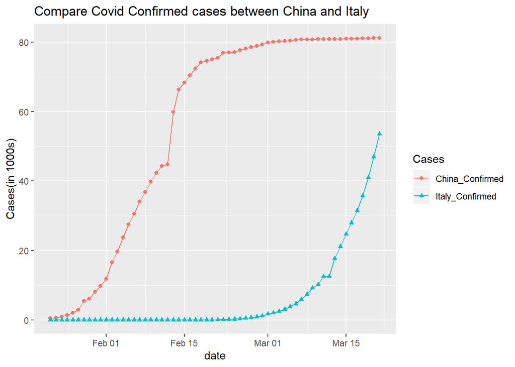

The **Compare Covid Confirmed cases between China and Italy** graph shows the comparison between China’s covid confirmed case and Italy’s covid confirmed case by date. China and Italy have the most covid confirmed cases compared to other countries and this is the reason I choose these two countries. China’s confirmed cases sharply increases around Feburary 15, and Italy’s confirmed cases suddenly increases around March 13-15. By this graph, I found that even though Italy’s covid confirmed cases appeared later than China, Italy’s covid confirmed cases increase quickly. Whereas China’s covid confirmed cases seem to be slowing down since March.

## 5. Conclusion

5.1. What did you learn about COVID-19?

- Covid Recovery rate is pretty low based on the analysis. Also, I can find that the number of confirmed cases per day is not increasing as much as it did during the dates, Feburary 1st through Feburary 15th, in China. Other counties excluding China seem to have lots of confirmed cases one month later than China.

5.2. Do your findings match what you hear in the media?

- Yes. This is because the covid 19 first appeared in China before Feburary, which did not greatly affect other countries. A month or month and a half later, lots of covid confirmed cases appear in other countries. As I analyzed the data in this project, other country’s covid infection increased around a month later than they appear in China.

5.3. If you were to explain and advise university officials on the spread of this virus, how would you describe it?

- Worldwide, the number of covid confirmed cases greatly increased after around two months. The death rate begin to increas increased around half a month after the steady increases of confirmed cases. Comparing the data collected for the death rate with the confirmed cases rate, after two months the confirmed cases exponentially grow, while the death rate continue to steadily increasse. Since the spread of virus is quick, people should stay at home.